# Lab04_report

### РОССИЙСКИЙ УНИВЕРСИТЕТ ДРУЖБЫ НАРОДОВ

#### Факультет физико-математических и естественных наук

#### Кафедра информационных технологий

## ОТЧЕТ ПО ЛАБОРАТОРНОЙ РАБОТЕ № 4

### Дисциплина: Информационный анализ данных

##### Студент: Ильин Никита

##### Группа: НФИбд-01-19

## Москва 2022

Вариант 23

Coil 1999 Competition Data Data Set

Название файла: analysis.data

Ссылка: http://archive.ics.uci.edu/ml/datasets/Coil+1999+Competition+Data

Первый признак: столбец No 4

Второй признак: столбец No 5

Третий признак: столбец No 6

Класс: season (столбец No 1)

Метод обработки пропущенных значений – медиана признака

Метод нормализации признаков – стандартизация

Алгоритм снижения размерности данных – одномерный отбор признаков (SelectKBest)

Метод валидации модели – кросс-валидация по отдельным объектам

Показатель качества модели – полнота (recall)

## Задание

Для закрепленного за Вами варианта лабораторной работы:

1. Считайте из заданного набора данных репозитария UCI значения трех признаков и метки класса.
2. Если среди меток класса имеются пропущенные значения, то удалите записи с пропущенными метками класса. Если в признаках имеются пропущенные значения, то замените пропущенные значения, используя метод, указанный в индивидуальном задании. Если количество различных меток классов превышает 4, то уменьшите количество классов.
3. Нормализуйте признаки набора данных методом, указанным в индивидуальном задании.
4. Визуализируйте набор данных в виде точек трехмерного пространства с координатами, соответствующими трем признакам, отображая точки различных классов разными цветами. Подпишите оси и рисунок, создайте легенду набора данных.
5. Используя алгоритм снижения размерности данных, указанный в индивидуальном задании, уменьшите размерность признакового пространства до двух и визуализируйте набор данных в виде точек на плоскости, отображая точки различных классов разными цветами. Подпишите оси и рисунок, создайте легенду набора данных.
6. Используя разделение набора данных из двух признаков на обучающую и тестовую выборки в соотношении 75% на 25%, проведите классификацию тестовой выборки с помощью метода К ближайших соседей для различных значений К и определите оптимальное значение параметра К с минимальной долей ошибок.
7. Для найденного значения K постройте и выведите на экран отчет о классификации и матрицу ошибок.
8. Создайте модели классификации точек набора данных из трех признаков на базе следующих классификаторов:
- наивного байесовского классификатора
- классификатора метода К ближайших соседей для значения К, определенного в п. 6.
1. Используя указанный в индивидуальном задании метод валидации модели, проведите для набора данных из трех признаков оценку качества классификаторов из п. 8 относительно показателя, указанного в индивидуальном задании, и выведите на экран среднее значение и дисперсию этого показателя.
2. Определите, какой из классификаторов позволяет получить более высокое среднее значение показателя классификации, проведите классификацию точек набора данных этим классификатором и визуализируйте набор данных в виде точек трехмерного пространства с координатами, соответствующими трем признакам, отображая точки различных прогнозируемых классов разными цветами. Подпишите оси и рисунок, создайте легенду набора данных.

### Выполнение

1. Считайте из заданного набора данных репозитария UCI значения трех признаков и метки класса.

```python
from sklearn import datasets
import numpy as np
import matplotlib.pyplot as plt
import pandas as pd
```

```python
data = pd.read_csv("analysis.data", sep=",", header = None)[[0, 3, 4, 5]]
data
```

|  | 0 | 3 | 4 | 5 |
| --- | --- | --- | --- | --- |
| 0 | winter | 8.00000 | 9.80000 | 60.80000 |
| 1 | spring | 8.35000 | 8.00000 | 57.75000 |
| 2 | autumn | 8.10000 | 11.40000 | 40.02000 |
| 3 | spring | 8.07000 | 4.80000 | 77.36400 |
| 4 | autumn | 8.06000 | 9.00000 | 55.35000 |
| ... | ... | ... | ... | ... |
| 195 | autumn | 8.40000 | 8.40000 | 17.37500 |
| 196 | spring | 8.30000 | 10.60000 | 14.32000 |
| 197 | autumn | 8.20000 | 7.00000 | 139.98900 |
| 198 | winter | 8.00000 | 7.60000 | XXXXXXX |
| 199 | summer | 8.50000 | 6.70000 | 82.85200 |

200 rows × 4 columns

1. Если среди меток класса имеются пропущенные значения, то удалите записи с пропущенными метками класса. Если в признаках имеются пропущенные значения, то замените пропущенные значения, используя метод, указанный в индивидуальном задании. Если количество различных меток классов превышает 4, то уменьшите количество классов.

```python
data = data.replace('XXXXXXX', np.NaN)
```

```python
data.isnull().sum(axis=0)
```

```
0     0
3     1
4     2
5    10
dtype: int64
```

```python
data = data.fillna(data.median())
```

```python
data.isnull().sum(axis=0)
```

```
0    0
3    0
4    0
5    0
dtype: int64
```

```python
data.groupby(0).count()
```

| 0 | 3 | 4 | 5 |
| --- | --- | --- | --- |
| autumn | 40 | 40 | 40 |
| spring | 53 | 53 | 53 |
| summer | 45 | 45 | 45 |
| winter | 62 | 62 | 62 |

1. Нормализуйте признаки набора данных методом, указанным в индивидуальном задании.

```python
from sklearn.preprocessing import StandardScaler

X = data[[3, 4, 5]]

scaler = StandardScaler().fit(X)
rescaledX = scaler.transform(X)

print(rescaledX[0:5,:])
```

```
[[-0.02011536  0.28447224  0.38846466]
 [ 0.56780762 -0.47367113  0.32155999]
 [ 0.14786263  0.95837746 -0.06736456]
 [ 0.09746923 -1.82148158  0.75181188]
 [ 0.08067143 -0.05248037  0.26891369]]
```

1. Визуализируйте набор данных в виде точек трехмерного пространства с координатами, соответствующими трем признакам, отображая точки различных классов разными цветами. Подпишите оси и рисунок, создайте легенду набора данных.

```python
from mpl_toolkits import mplot3d
%matplotlib inline
import numpy as np
import matplotlib.pyplot as plt
```

```python
cleanup_nums = {0: {"winter": 0, "spring": 1, "summer": 2, "autumn": 3}}
```

```python
data.replace(cleanup_nums, inplace=True)
data
```

|  | 0 | 3 | 4 | 5 |
| --- | --- | --- | --- | --- |
| 0 | 0 | 8.00000 | 9.80000 | 60.80000 |
| 1 | 1 | 8.35000 | 8.00000 | 57.75000 |
| 2 | 3 | 8.10000 | 11.40000 | 40.02000 |
| 3 | 1 | 8.07000 | 4.80000 | 77.36400 |
| 4 | 3 | 8.06000 | 9.00000 | 55.35000 |
| ... | ... | ... | ... | ... |
| 195 | 3 | 8.40000 | 8.40000 | 17.37500 |
| 196 | 1 | 8.30000 | 10.60000 | 14.32000 |
| 197 | 3 | 8.20000 | 7.00000 | 139.98900 |
| 198 | 0 | 8.00000 | 7.60000 | 32.73 |
| 199 | 2 | 8.50000 | 6.70000 | 82.85200 |

200 rows × 4 columns

```python
data[[3, 4, 5]] = data[[3, 4, 5]].astype('float')
data.dtypes
```

```
0      int64
3    float64
4    float64
5    float64
dtype: object
```

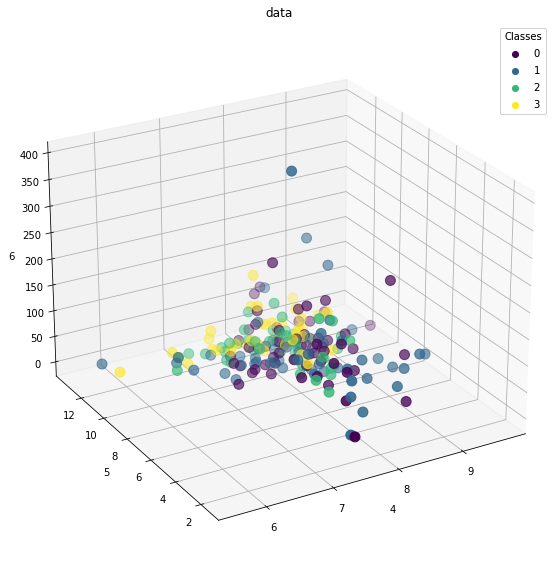

```python
fig = plt.figure(figsize=(12,10))
ax = plt.axes(projection='3d')
Y = data[0]

xs = data[3]
ys = data[4]
zs = data[5]

scatter = ax.scatter( xs, ys, zs, c=Y,s=100 )
ax.set_xlabel("4")
ax.set_ylabel("5")
ax.set_zlabel("6")
ax.set_title("data")
legend1 = ax.legend(*scatter.legend_elements(), title="Classes")
ax.add_artist(legend1)
ax.view_init( azim=-120, elev=25 );
```

1. Используя алгоритм снижения размерности данных, указанный в индивидуальном задании, уменьшите размерность признакового пространства до двух и визуализируйте набор данных в виде точек на плоскости, отображая точки различных классов разными цветами. Подпишите оси и рисунок, создайте легенду набора данных.

```python
# отбор признаков при помощи одномерных статистических тестов
from sklearn.feature_selection import SelectKBest,chi2

print("\nИсходный набор данных:\n",data.head())

# отбор признаков
test = SelectKBest(score_func=chi2, k=2)
fit = test.fit(X, Y)

# оценки признаков
print("\nОценки признаков:\n",fit.scores_)

cols = test.get_support(indices=True)
df_new = data.iloc[:,cols]
print("\nОтобранные признаки:\n",df_new.head())
```

```
Исходный набор данных:
    0     3     4       5
0  0  8.00   9.8  60.800
1  1  8.35   8.0  57.750
2  3  8.10  11.4  40.020
3  1  8.07   4.8  77.364
4  3  8.06   9.0  55.350

Оценки признаков:
 [  0.17057771  17.18634142 118.28439179]

Отобранные признаки:
       3     4
0  8.00   9.8
1  8.35   8.0
2  8.10  11.4
3  8.07   4.8
4  8.06   9.0
```

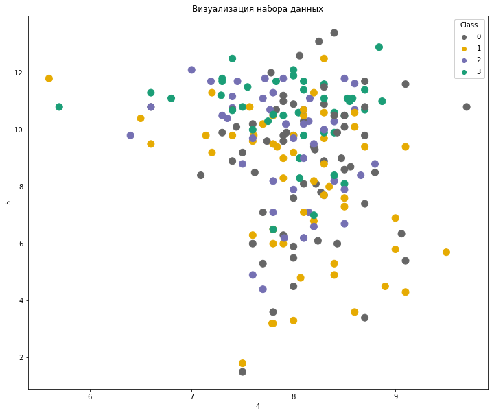

```python
fig, ax = plt.subplots(figsize=(12,10))
scatter = ax.scatter(df_new[[3]], df_new[[4]], s=100, c=Y, cmap=plt.cm.Dark2_r)
ax.set_xlabel("4")
ax.set_ylabel("5")
ax.set_title("Визуализация набора данных")
legend1 = ax.legend(*scatter.legend_elements(), title="Class")
ax.add_artist(legend1)
```

1. Используя разделение набора данных из двух признаков на обучающую и тестовую выборки в соотношении 75% на 25%, проведите классификацию тестовой выборки с помощью метода К ближайших соседей для различных значений К и определите оптимальное значение параметра К с минимальной долей ошибок.

```python
from sklearn.model_selection import train_test_split
from sklearn.neighbors import KNeighborsClassifier
```

```python
df_new
```

|  | 3 | 4 |
| --- | --- | --- |
| 0 | 8.00 | 9.8 |
| 1 | 8.35 | 8.0 |
| 2 | 8.10 | 11.4 |
| 3 | 8.07 | 4.8 |
| 4 | 8.06 | 9.0 |
| ... | ... | ... |
| 195 | 8.40 | 8.4 |
| 196 | 8.30 | 10.6 |
| 197 | 8.20 | 7.0 |
| 198 | 8.00 | 7.6 |
| 199 | 8.50 | 6.7 |

200 rows × 2 columns

```python
X2 = np.array(df_new)
X2.shape, Y.shape
```

```
((200, 2), (200,))
```

```python
X_train, X_test, y_train, y_test = train_test_split(X2, Y, test_size=0.25)
```

```python
best_score = 0.0
best_k = -1

for k in range(1, 151):
    kNN_clf = KNeighborsClassifier(n_neighbors=k)
    kNN_clf.fit(X_train, y_train.ravel())
    score = kNN_clf.score(X_test, y_test)
    if score > best_score:
        best_k = k
        best_score = score
```

```python
print("Лучшее k =", best_k)
print("Лучшая оценка =", best_score)
```

```
Лучшее k = 20
Лучшая оценка = 0.42
```

```python
kNN_clf = KNeighborsClassifier(n_neighbors=best_k)
kNN_clf.fit(X_train, y_train.ravel())
```

```
KNeighborsClassifier(n_neighbors=20)
```

1. Для найденного значения K постройте и выведите на экран отчет о классификации и матрицу ошибок.

```python
from sklearn.metrics import classification_report,confusion_matrix

y_pred = kNN_clf.predict(X_test)

conf_mat=confusion_matrix(y_test,y_pred)
print(conf_mat)
```

```
[[7 3 0 4]
 [3 5 1 0]
 [8 1 2 6]
 [1 0 2 7]]
```

```python
print(classification_report(y_test,y_pred))
```

```
              precision    recall  f1-score   support

           0       0.37      0.50      0.42        14
           1       0.56      0.56      0.56         9
           2       0.40      0.12      0.18        17
           3       0.41      0.70      0.52        10

    accuracy                           0.42        50
   macro avg       0.43      0.47      0.42        50
weighted avg       0.42      0.42      0.38        50
```

```python
print("Доля ошибок неправильной классификации:",round(np.mean(y_pred!=y_test),3))
```

```
Доля ошибок неправильной классификации: 0.58
```

1. Создайте модели классификации точек набора данных из трех признаков на базе следующих классификаторов:
- наивного байесовского классификатора
- классификатора метода К ближайших соседей для значения К, определенного в п. 6.

```python
X_train, X_test, y_train, y_test = train_test_split(X, Y, test_size=0.3)
```

```python
from sklearn.naive_bayes import GaussianNB

nbc = GaussianNB()
nbc.fit(X_train,y_train)
y_pred_nbc = nbc.predict(X_test)
y_pred_nbc
```

```
array([1, 3, 2, 3, 3, 1, 3, 2, 0, 3, 3, 3, 3, 2, 3, 1, 0, 0, 0, 3, 3, 3,
       2, 2, 3, 3, 0, 3, 3, 0, 2, 0, 0, 3, 0, 0, 3, 1, 3, 3, 3, 3, 3, 3,
       1, 0, 0, 0, 2, 0, 3, 3, 3, 0, 2, 1, 3, 1, 2, 3], dtype=int64)
```

```python
kNN_clf2 = KNeighborsClassifier(n_neighbors = best_k) # создаем классификатор
kNN_clf2.fit(X_test, y_test)                 # обучаем классификатор
y_pred_kNN_clf = kNN_clf2.predict(X_test)
y_pred_kNN_clf
```

```
array([1, 3, 1, 3, 3, 1, 0, 0, 3, 3, 3, 0, 3, 0, 3, 1, 3, 3, 3, 1, 1, 3,
       1, 1, 0, 1, 3, 3, 1, 3, 3, 1, 3, 0, 1, 3, 1, 1, 0, 1, 1, 0, 1, 3,
       1, 0, 1, 1, 0, 3, 1, 1, 3, 1, 3, 1, 1, 1, 1, 1], dtype=int64)
```

```python
y3_pred = kNN_clf2.predict(X_test)
mislabel = np.sum((y_test!=y3_pred))
print("Количество неправильно классифицированных точек из ", len(y_test), " точек тестового множества для наивного байесовского классификатора равно ",mislabel)
```

[output not shown]

1. Используя указанный в индивидуальном задании метод валидации модели, проведите для набора данных из трех признаков оценку качества классификаторов из п. 8 относительно показателя, указанного в индивидуальном задании, и выведите на экран среднее значение и дисперсию этого показателя.

кросс-валидация по отдельным объектам  
полнота (recall)

```python
from sklearn.model_selection import cross_val_score
```

```python
# Leave One Out Cross-Validation

from sklearn.model_selection import LeaveOneOut

loocv = LeaveOneOut()

results_loocv = cross_val_score(nbc, X, Y, scoring='recall_micro', cv=loocv)
print("Среднее значение: %.2f%%, дисперсия: %.2f%%" % (results_loocv.mean()*100.0, results_loocv.var()*100.0))
```

```
Среднее значение: 30.00%, дисперсия: 21.00%
```

```python
results_loocv = cross_val_score(kNN_clf2, X, Y, scoring='recall_micro', cv=loocv)
print("Среднее значение: %.2f%%, дисперсия: %.2f%%" % (results_loocv.mean()*100.0, results_loocv.var()*100.0))
```

```
Среднее значение: 26.00%, дисперсия: 19.24%
```

1. Определите, какой из классификаторов позволяет получить более высокое среднее значение показателя классификации, проведите классификацию точек набора данных этим классификатором и визуализируйте набор данных в виде точек трехмерного пространства с координатами, соответствующими трем признакам, отображая точки различных прогнозируемых классов разными цветами. Подпишите оси и рисунок, создайте легенду набора данных.

```python
X_test = X_test.astype(float)
```

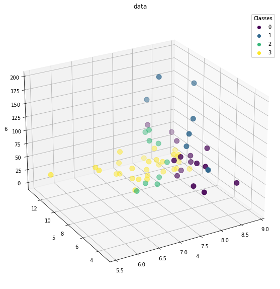

```python
fig = plt.figure(figsize=(12,10))
ax = plt.axes(projection='3d')
Y = data[0]

xs = X_test[3]
ys = X_test[4]
zs = X_test[5]

scatter = ax.scatter( xs, ys, zs, c=y_pred_nbc,s=100 )
ax.set_xlabel("4")
ax.set_ylabel("5")
ax.set_zlabel("6")
ax.set_title("data")
legend1 = ax.legend(*scatter.legend_elements(), title="Classes")
ax.add_artist(legend1)
ax.view_init( azim=-120, elev=25 );
```